# Inference demos — figures for §4

Running example: fit RWW global coupling G (and recurrence w) to empirical FC

Authors

Affiliations

Leon Stefanovski

Charité University Medicine Berlin

Marius Pille

Berlin Institute of Health at Charité University Medicine

Leon Martin

Berlin Institute of Health at Charité University Medicine

This notebook produces the figures embedded in `_slides-section-4.qmd`. It re-uses the Reduced Wong-Wang setup from `RWW.qmd` but pins the inference *running example* to **fitting `G` (and `w`) so simulated FC matches empirical FC**.

Each figure is saved to `img/section-4/` and referenced from the slides by path. Re-run this notebook whenever the §4 figures need to change.

## 1 Setup

```python
import os
cpu = True
if cpu:
    N = 8
    os.environ["XLA_FLAGS"] = f"--xla_force_host_platform_device_count={N}"

import copy
import numpy as np
import matplotlib.pyplot as plt
import jax
import jax.numpy as jnp
import optax

jax.config.update("jax_enable_x64", True)

from tvboptim.types import Parameter, Space, GridAxis, UniformAxis, DataAxis
from tvboptim.utils import set_cache_path, cache
from tvboptim.execution import ParallelExecution
from tvboptim.optim.optax import OptaxOptimizer
from tvboptim.optim.callbacks import MultiCallback, DefaultPrintCallback, SavingCallback

from tvboptim.experimental.network_dynamics import Network, prepare
from tvboptim.experimental.network_dynamics.dynamics.tvb import ReducedWongWang
from tvboptim.experimental.network_dynamics.coupling import FastLinearCoupling
from tvboptim.experimental.network_dynamics.graph import DenseGraph
from tvboptim.experimental.network_dynamics.solvers import Heun
from tvboptim.experimental.network_dynamics.noise import AdditiveNoise
from tvboptim.data import load_structural_connectivity, load_functional_connectivity
from tvboptim.observations.tvb_monitors.bold import Bold
from tvboptim.observations.observation import compute_fc, rmse

set_cache_path("./inference_demos")

FIG_DIR = "../img/section-4"
DPI = 200
os.makedirs(FIG_DIR, exist_ok=True)

def savefig(name, **kw):
    path = os.path.join(FIG_DIR, name)
    plt.savefig(path, dpi=DPI, bbox_inches="tight", **kw)
    print(f"saved → {path}")
```

## 2 Network and loss

```python
weights, lengths, region_labels = load_structural_connectivity(name="dk_average")
weights = weights / np.max(weights)
n_nodes = weights.shape[0]
fc_target = load_functional_connectivity(name="dk_average")

graph = DenseGraph(weights, region_labels=region_labels)
dynamics = ReducedWongWang(w=0.5, I_o=0.32, INITIAL_STATE=(0.3,))
coupling = FastLinearCoupling(local_states=["S"], G=0.5)
noise = AdditiveNoise(sigma=0.00283, apply_to="S")

network = Network(
    dynamics=dynamics,
    coupling={"instant": coupling},
    graph=graph,
    noise=noise,
)

t1 = 120_000
dt = 4.0
model, state = prepare(network, Heun(), t1=t1, dt=dt)

# warm-up transient
result_init = model(state)
network.update_history(result_init)
model, state = prepare(network, Heun(), t1=t1, dt=dt)

bold_monitor = Bold(period=1000.0, downsample_period=4.0, voi=0, history=result_init)

def observation(s):
    r = model(s)
    b = bold_monitor(r)
    return compute_fc(b, skip_t=20)

def loss(s):
    return rmse(observation(s), fc_target)
```

## 3 2D loss landscape over (w, G)

The running example is the global-coupling fit. We sweep `w` *and* `G` because (a) it gives a nicer 2D picture for the slides and (b) brain network models typically show a **degeneracy**: a curved valley of roughly equivalent (`w`, `G`) combinations all produce comparable FC fits.

```python
n_grid = 32

grid_state = copy.deepcopy(state)
grid_state.dynamics.w = GridAxis(0.001, 0.7, n_grid)
grid_state.coupling.instant.G = GridAxis(0.001, 0.7, n_grid)
grid = Space(grid_state, mode="product")

@cache("explore_2d", redo=False)
def explore_2d():
    exec = ParallelExecution(loss, grid, n_pmap=8)
    return exec.run()

results_2d = explore_2d()
df_results = results_2d.to_dataframe()  # columns: coupling.instant.G, dynamics.w, value

# pivot to a (w × G) grid for imshow
loss_grid = df_results.pivot(
    index="dynamics.w", columns="coupling.instant.G", values="value"
).sort_index().sort_index(axis=1)
G_axis = loss_grid.columns.values.astype(float)
w_axis = loss_grid.index.values.astype(float)
```

```
saved → ../img/section-4/loss_surface_2d.png
```

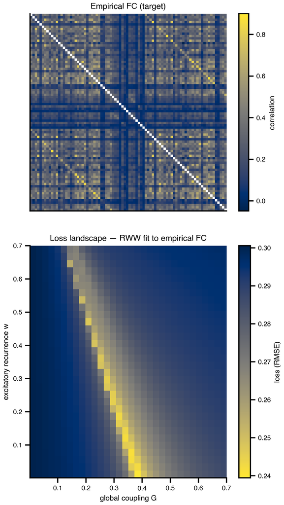

Figure 1: Top: empirical FC we’re fitting to. Bottom: loss landscape over (G, w). The curved low-loss valley — many parameter combinations fit FC about equally well — is the kind of degeneracy that brain network models routinely exhibit.

```python
fig, (ax_fc, ax) = plt.subplots(2, 1, figsize=(5.0, 9.0))

fc_show = np.array(fc_target).copy()
np.fill_diagonal(fc_show, np.nan)
im_fc = ax_fc.imshow(fc_show, cmap="cividis", vmax=0.9)
ax_fc.set_xticks([])
ax_fc.set_yticks([])
ax_fc.set_title("Empirical FC (target)")
plt.colorbar(im_fc, ax=ax_fc, shrink=0.85, label="correlation")

im = ax.imshow(
    loss_grid.values,
    cmap="cividis_r",
    extent=[G_axis.min(), G_axis.max(), w_axis.min(), w_axis.max()],
    origin="lower",
    aspect="auto",
    interpolation="none",
)
plt.colorbar(im, ax=ax, label="loss (RMSE)")
ax.set_xlabel("global coupling G")
ax.set_ylabel("excitatory recurrence w")
ax.set_title("Loss landscape — RWW fit to empirical FC")

plt.tight_layout()
savefig("loss_surface_2d.png")
plt.show()
```

## 4 1D slice along G

Slice the 2D landscape along `G` at a fixed `w` (the model default `w = 0.5`). This is the “easy to picture” 1D view — but the 2D plot above is what reveals the degeneracy.

```
saved → ../img/section-4/loss_surface_1d.png
```

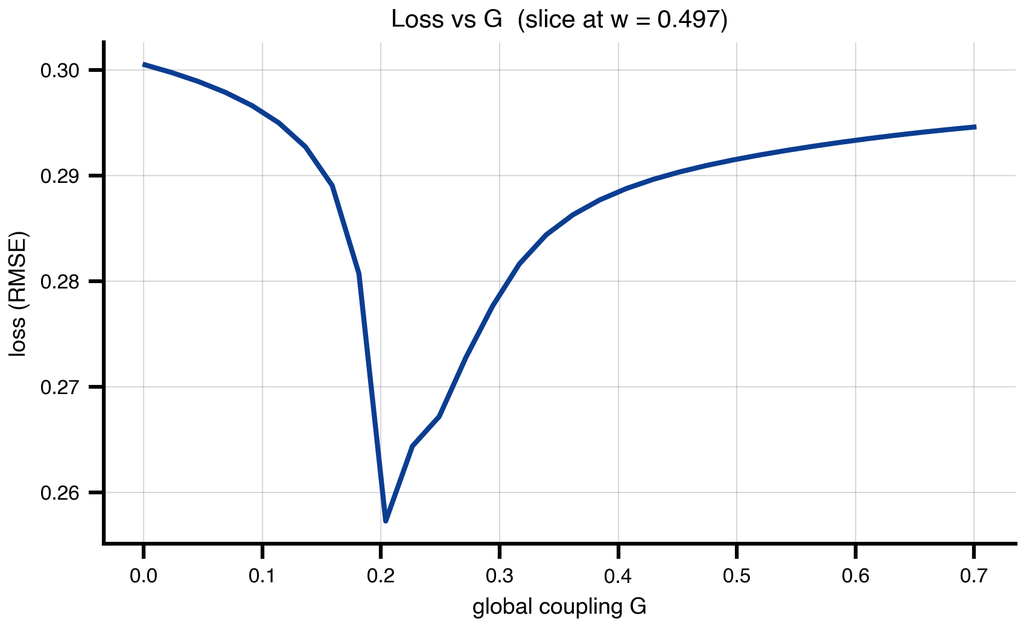

Figure 2: 1D slice of the loss along G at fixed w = 0.5.

```python
w_slice = 0.5
i_w_slice = int(np.argmin(np.abs(w_axis - w_slice)))
loss_slice = loss_grid.values[i_w_slice, :]

fig, ax = plt.subplots(figsize=(6.5, 3.6))
ax.plot(G_axis, loss_slice, color="#0b3d91", linewidth=2)
ax.set_xlabel("global coupling G")
ax.set_ylabel("loss (RMSE)")
ax.set_title(f"Loss vs G  (slice at w = {w_axis[i_w_slice]:.3f})")
ax.grid(True, alpha=0.3)
savefig("loss_surface_1d.png")
plt.show()
```

## 5 Random search over (w, G)

Same parameter ranges as the grid scan, but 100 samples drawn uniformly and zipped into a single `Space`.

```python
n_random = 100

random_state = copy.deepcopy(state)
random_state.dynamics.w = UniformAxis(0.001, 0.7, n_random)
random_state.coupling.instant.G = UniformAxis(0.001, 0.7, n_random)
random_space = Space(random_state, mode="zip", key=jax.random.key(42))

@cache("explore_random", redo=False)
def explore_random():
    exec = ParallelExecution(loss, random_space, n_pmap=8)
    return exec.run()

results_random = explore_random()
df_random = results_random.to_dataframe()
```

```
saved → ../img/section-4/random_search.png
```

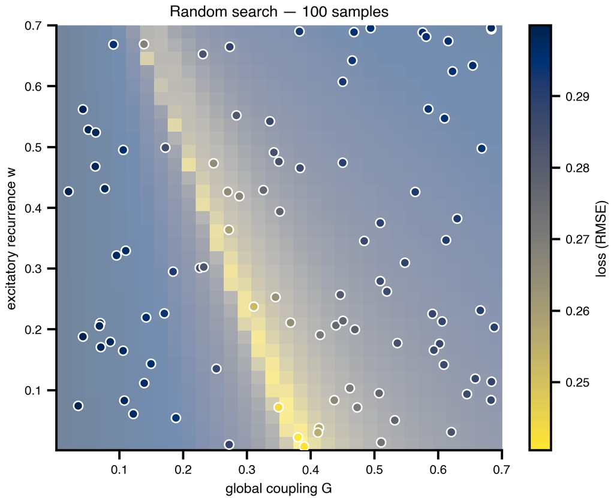

Figure 3: Random search: 100 samples drawn uniformly over (G, w), overlaid on the grid-scan loss landscape. Marker color = loss; the search threads through the same low-loss valley without paying the N² grid cost.

```python
G_rand = df_random["coupling.instant.G"].values.astype(float)
w_rand = df_random["dynamics.w"].values.astype(float)
loss_rand = df_random["value"].values.astype(float)

fig, ax = plt.subplots(figsize=(6.5, 5.0))
im = ax.imshow(
    loss_grid.values,
    cmap="cividis_r",
    extent=[G_axis.min(), G_axis.max(), w_axis.min(), w_axis.max()],
    origin="lower",
    aspect="auto",
    interpolation="none",
    alpha=0.55,
)
sc = ax.scatter(G_rand, w_rand, c=loss_rand, cmap="cividis_r",
                s=35, edgecolors="white", linewidths=1.0, zorder=3)
plt.colorbar(sc, ax=ax, label="loss (RMSE)")
ax.set_xlabel("global coupling G")
ax.set_ylabel("excitatory recurrence w")
ax.set_title(f"Random search — {n_random} samples")
savefig("random_search.png")
plt.show()
```